# CSCI 2436 Homework 1

Due: February 17, 2026

## Submission

This is NOT an assignment to submit on Blackboard. Please complete all problems and be prepared to show your work in person during the review session on Feb 17 to receive credit.

## 1. Algorithm Analysis

Consider the following algorithm:

```java
void mysteryFunction(int n) {
    int count = 0;
    for (int i = 0; i < n; i++) {
        for (int j = 0; j < i; j++) {
            for (int k = 0; k < j; k++) {
                count++;
            }
        }
    }
}
```

1. Determine the total number of times the statement `count++` is executed as a function of $n$.
2. Express this count using Big-O notation.
3. Analyze the space complexity of the function.

## 2. Infix to Postfix Conversion

Convert the infix expression $a*(b+c)/d$ to its postfix form. After reading each character of the expression, illustrate the state of the stack and the postfix expression.

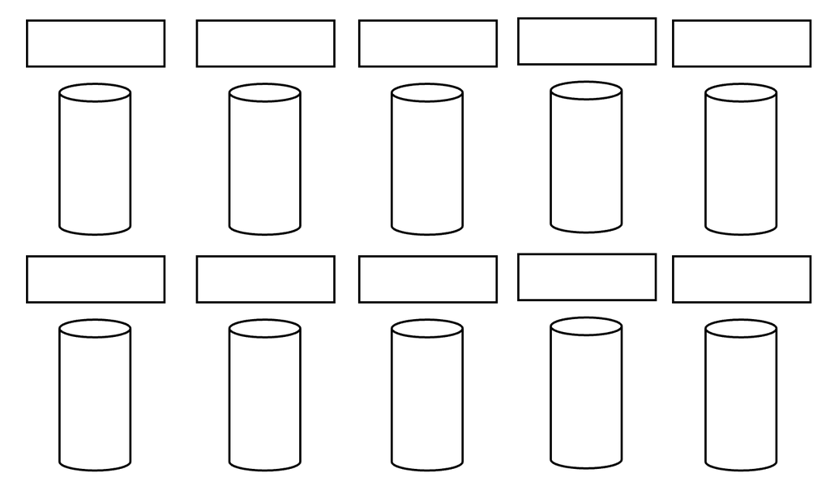

Stack and Postfix Diagram

## 3. Backspace Key with a Stack

When typing on a keyboard, we often use the *backspace* key to correct mistakes. Suppose we only use a **stack** to process a sequence of characters, including backspace (←). For example:

```
com←mpte←←utr←er
```

This should result in the final string: `"computer"`

1. Design an algorithm that uses only stack(s) to process a sequence of characters, including backspace. Complete the pseudocode in the box below.
2. Analyze the time and space complexity in Big-O notation of your algorithm.

```java
Algorithm ProcessString(S):
    Create an empty stack s
    For each char c in S:
        If c is not backspace:
            //Your code below (1 line)


        Else if stack is not empty:
            //Your code below (1 line)


    //Construct output string from stack s
    //Your code below (4~5 lines)






    Return the output string
```

## 4. Queue Using Two Stacks

- A **queue** is a linear data structure that follows **First-In-First-Out (FIFO)**:
  - **Enqueue**: Inserts an element at the back.
  - **Dequeue**: Removes and returns the front element.
- A **stack** follows **Last-In-First-Out (LIFO)**. We can **simulate a queue using two stacks**:
  - **Input Stack**: Stores incoming elements via `enqueue`.
  - **Output Stack**: Reverses order for `dequeue` operations.
1. Design an algorithm to implement a queue using two stacks. Complete the pseudocode for:
   - `enqueue(value)`: Inserts `value` into the queue.
   - `dequeue()`: Removes and returns the front element.
2. Analyze the time and space complexity of both operations.

```java
Algorithm Enqueue(value):
    //Push value onto input stack
    //Your code below (1 line)


Algorithm Dequeue():
    If output stack is empty:
        //Transfer all elements from input stack to output stack
        //Your code below (3~4 lines)





    Else:
        //Output stack not empty: front element is already on top
        //(nothing to do here)

    //Pop and return the front element from output stack
    //Your code below (1 line)

    Return the front element
```